# To admit limitation: Yermack (2014) and other guides

Richard (d05723007)

NTU, May 2017

# The author: David Yermack

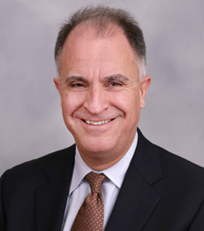

David Yermack

- Chair, Finance Department at NYU Stern School of Business
- H-index: 26
- Citation: 16590

**Title of paper:** “Tailspotting: Identifying and profiting from CEO vacation trips”

# The idea of this paper

- When CEOs are on their vacation trips, do these events affect the corporate news disclosures?
- He finds that:
  - CEOs go away right after important news disclosures
  - CEOs return offices just before subsequent news announcements
  - During the vacations, less important news is announced
  - Thus, volatility drops by 13% during the vacations
  - More likely to disclose the mandatory Form 8-K lately

# An example: Figure 1

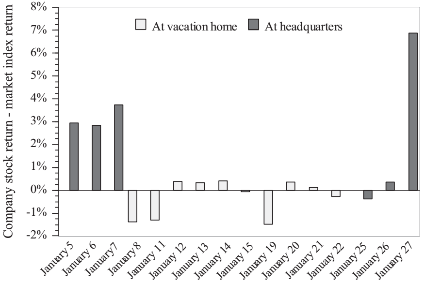

Figure 1

This figure shows Boeing Co. daily excess stock returns over CRSP value-weighted market index, during January 2010.

- January 7: Boeing announced its deliveries increase 28% in 2009
- January 27: Boeing announced better-than-expected earning results for the 4th quarter of 2009
- Little news of significance was announced between those two dates

# What I think for 1st paragraph?

- A plausible motivation:
  - Why CEO vacation is important and could affect corporate news disclosure?
  - Literature about: news disclosure and CEO lifes
- A good example of this event

# His approach

**1. Introduction**

1. P1: Research question (1st sentence) and results
2. P2: One example: Boeing Co. and Figure 1
3. P3-P5: three hypotheses and how fit the results to these hypotheses. He also indicates the potential limitations.
4. P6-P7: Contributions
5. P8: Outline of paper

**2. Literature review**

1. P1-P3: Literature reviews about news disclosure, CEO life, dislosure quality and performance
2. P4: Contribution

# Introduction (P1)

*Directly tell readers the results:*

This paper shows a close connection between the timing of corporate news disclosures and chief executive officers’ (CEOs’) absences from headquarters. I identify CEO absences by merging publicly available flight histories of corporate jets with real estate records of CEOs’ property ownership near leisure destinations. I find that CEOs go to their vacation homes just after companies report favorable news, and CEOs return to headquarters right before subsequent news is released. More good news is released when CEOs are back at work, and CEOs appear not to leave headquarters at all if a firm has adverse news to disclose. When CEOs are away from the office, stock prices behave quietly with sharply lower volatility. Volatility increases immediately when CEOs return to work. Mandatory Form 8-K disclosures of material company news are more likely to be filed late if news occurs while CEOs are at their vacation homes.

# Introduction (P2)

An example illustrating many of these patterns appears in Fig. 1. On January 7, 2010, aerospace manufacturer Boeing Co. disclosed a 28% increase in annual commercial airliner deliveries and issued an earnings forecast for the year ahead. Boeing stock rose 4%, capping three days in which it outperformed the market by almost 10%. The company’s shares were quiet for the next several weeks, not moving significantly again until January 27, when Boeing announced strong quarterly earnings and its stock rose more than 7%. In between these announcements, Boeing’s CEO appears to have been at his vacation home, an inference based upon Federal Aviation Administration (FAA) records of company aircraft trips to and from an airport near his vacation residence in Hobe Sound, Florida. During this period, the annualized volatility of Boeing’s stock dropped to 0.16, an unusually low level for a major blue chip. During the three days before and three days after his trip, the volatility was more than twice as high at 0.40. I find patterns similar to Fig. 1 for a sample of 217 trips to vacation homes lasting five workdays or longer, taken by CEOs of 65 major US companies during the four year period 2007-2010.

# The coolest thing is coming!

[figure not shown]

The limitation of the paper

# How to admit limitation?

# How a big guy did?

- Distribute in three paragraphs at very first of the introduction.
- As direct as possible:
  - “A persuasive instrumental variable with these characteristics is hard to find.”
  - “Due to the difficulty of identifying a CEO’s business flights, the paper does not have …”
  - “and my inability to distinguish between them represents a limitation of the paper’s research design”

# Introduction (P3)

The paper’s results seem consistent with an agency cost hypothesis, under which CEOs could slow down their firms’ news disclosures for personal convenience on the days that they requisition company aircraft for golf or ski trips. However, the observed associations between news disclosures and vacation schedules could well be endogenous, if CEOs plan to be away from the office when the company expects to have little news to announce. To understand more clearly the direction of causation between disclosures and CEO absences, I conduct a variety of tests, examining how company news announcements change when CEOs return to headquarters at unexpected times. I also estimate a bivariate probit model of news days and vacation days, in which weather at the CEO’s vacation site is used as an instrumental variable that should be associated with trips to the vacation home but should not be connected to company news developments. Much of the analysis from these tests supports the agency interpretation, with news releases appearing to occur less frequently simply because the CEO is absent from the office. However, it is difficult to test causation in the other direction, which would require an instrumental variable associated with news at headquarters but uncorrelated with the CEO’s decision to take time off. A persuasive instrumental variable with these characteristics is hard to find. In addition, overall patterns of CEO vacations do not provide clear-cut support for the agency hypothesis. CEOs do not seem to over consume leisure, as they spend about 17 workdays a year at their vacation homes, in line with the schedules of typical mid-level managers. Many of their trips are short, and some appear to be interrupted for returns to headquarters when required.

# Introduction (P4)

A number of benign explanations also seem consistent with results in the paper. Some CEO responsibilities, such as secret merger negotiations, could require meetings at remote locations and put the CEO out of contact with headquarters or the news media. This distance hypothesis implies that corporate disclosure could be affected by the CEO’s mere absence from headquarters, even for business trips, due to logistical complications. In principle one could test this conjecture by using business-related aircraft flights to identify the CEO’s days away from headquarters and comparing news on those days with disclosures on vacation days. However, CEOs’ business trips are hard to pinpoint, because passenger manifests are not available for individual flights. Due to the difficulty of identifying a CEO’s business flights, the paper does not have a benchmark for differentiating how company news disclosures change when the CEO leaves for vacation compared with routine trips away from headquarters for business.

# Introduction (P5)

An effort hypothesis would suggest that companies disclose less news when the CEO is at his vacation home not because he is a great distance away, but because he is working less and producing less news. The effort hypothesis seems plausible because technology should allow most managers to communicate with headquarters from afar. This hypothesis is difficult to test directly, as we cannot observe the CEO’s hour-to-hour activities at any location. Evidence that CEOs work less while at their vacation homes is circumstantial, based on their proximity to beaches, marinas, and ski resorts, as well as large perquisite disclosures for many of them of corporate aircraft use for personal reasons. However the effort hypothesis is difficult to separate empirically from the distance hypothesis, and my inability to distinguish between them represents a limitation of the paper’s research design.

# Introduction (P6)

This study illuminates a facet of corporate disclosure policy rarely noticed by investors or regulators. Since the 1930s US authorities have established detailed regulations for the timing of company disclosures by enacting rules such as Regulation FD and the Sarbanes-Oxley Act (SOX). Since it became effective in 2003, SOX has required companies to report a wide range of material events on Form 8-K within either two or four business days. Notwithstanding these regulations, my results indicate systematic coordination between public news disclosures and the personal schedules of company CEOs.

# Introduction (P7)

The movements of company aircraft to and from CEOs’ vacation residences provide visible signals of pending news announcements and silences. With a trivial amount of research and monitoring, investors could observe flights of corporate aircraft in real time between the headquarters airport and CEOs’ vacation locales, either by watching live FAA data on the Internet or stationing scouts for tailspotting of the tail numbers of planes that land at leisure airports favored by CEOs such as Nantucket, Massachusetts or Naples, Florida. This information could support straightforward trading strategies, such as using derivatives to bet on declines in volatility when a CEO arrives at his vacation airport and increases in volatility when he departs. A similar pattern of volatility changes tied to the arrival of transport vessels is described by Koudijs (2013) in his historical account of British company shares trading on the Amsterdam, Netherlands, exchange during the 18th century. By merging the schedules of mail boats carrying news from England with daily share price changes in Amsterdam, Koudijs shows that volatility of stocks rose markedly when English ships docked in Amsterdam. In this study, the mechanism by which information reaches the market is somewhat different than in Koudijs’s paper. Whereas the mail boats in 18th-century Europe transported market-relevant news from abroad directly to investors, a 21st-century CEO’s corporate jet seems to carry a gatekeeper who personally controls the release of news, and whose absence from headquarters implies silence by the firm.

# Introduction (P8)

The remainder of this paper is organized as follows. Section 2 presents a literature review connecting the results of this study to research in law, finance, and accounting. Section 3 describes the data collection and presents descriptive statistics about the sample. Section 4 contains an analysis of stock returns and changes in volatility when a CEO is out of the office at his vacation home, as well as an analysis of corporate news releases. Section 5 concludes the paper.

# Literature review (P1)

A large academic literature has investigated the strategic timing of news disclosure by corporations. These papers generally focus upon firms’ attempts to influence analysts and journalists or exploit gaps in investors’ attention. For instance, Patell and Wolfson (1982), Damodaran (1989), and many other studies find that firms release adverse news on late Friday afternoons or in the evenings after the stock exchange has closed. Dye (2010) studies conditions under which companies cluster or bunch several disclosures together to diminish the focus of investors upon any one announcement. Ahern and Sosyura (2014) show that, when negotiating stock-for-stock acquisitions, a bidder firm often floods the news media with positive announcements, attempting to drive its share price higher and obtain a more favorable exchange ratio with the target firm.

# Literature review (P2)

Delaying or advancing news based upon the CEO’s personal work schedule represents an additional aspect of disclosure policy that has not been previously noted by researchers. Numerous studies in the management field have analyzed top managers’ daily activities, though it is unusual for these papers to show direct associations between CEO schedules and companies’ financial performance. One exception is Bandiera, Guiso, Prat, and Sandun (2011), who study one week of detailed work diaries for CEOs of 94 large Italian companies, tracking such variables as the number of hours worked and the frequency of meetings with colleagues and customers. The authors find a positive association between company productivity, measured as sales per employee, and hours worked by CEOs, especially for hours spent inside the firm rather than outside the firm in meetings with, for example, investors or customers. Bennedsen, Pérez-Gonzalez, and Wolfenzon (2012) study CEO illnesses and find a negative relation between CEO hospitalizations and subsequent company profitability. In both of these papers, the outcome variables are reported at the annual level, in contrast to this study, which looks more finely at daily stock price behavior when a CEO is in or away from the office.

# Literature review (P3)

Previous literature suggests that if a company were to alter its disclosure practices to accommodate absences of top managers, investors could react negatively over time. When a company delays or reduces its news disclosures, research indicates that a number of financial problems arise for the firm. Most of these studies rely on indexes of firms’ disclosure quality created by analysts or other financial market professionals. These indexes evaluate firms according to the frequency, timeliness, and informativeness of their news announcements. According to this research, better corporate disclosure is associated with a lower cost of debt (Sengupta, 1998), greater liquidity for the firm’s stock (Welker, 1995), increased willingness of institutional investors to hold a company’s shares (Healy, Hutton, and Palepu, 1999; Bushee and Noe, 2000), and reduced litigation risk (Skinner, 1997). Leuz and Wysocki (2008) provide a survey of these studies.

# Literature review (P4)

My paper also extends a growing literature based upon CEOs’ corporate jet usage. While early research such as Rajan and Wulf (2006) and Yermack (2006) focuses upon connections between jet usage and company performance, this paper does not directly analyze the impact of jet flights. Instead, it employs data about CEOs’ air travel as an identification strategy for their absences from headquarters. Two other recent working papers use The Wall Street Journal’s Jet Tracker database, the same source employed in this study, to identify executive trips to specific locations. Bushee, Gerakos and Lee (2013) study executive trips to the money center cities of New York, New York, Boston, Massachusetts, Chicago, Illinois, and San Francisco, California, where the managers are likely to be meeting with bankers, analysts, or investors. Lee, Lowry, and Shu (2013) use aircraft travel records to compile data about the frequency of managers’ trips from headquarters to company subsidiaries and other business locations.

# Thank you

- Thank you for your time
- A useful link: [Professor Cochrane](http://faculty.chicagobooth.edu/john.cochrane/teaching/writing/)

> I don’t write a “roadmap” paragraph: “Section 2 sets out the model, section 3 discusses identification, section 4 gives the main results, section 5 checks for robustness, section 6 concludes.” It seems a waste of space; readers will figure it out when they get there and I save a paragraph against the editor’s page count.
- Reference:
1. Swales, J.M. and Feak, C.B., 2004. Academic writing for graduate students: Essential tasks and skills. Ann Arbor, University of Michigan Press, page 368.
2. [Manchester University Academic Phrasebank](http://www.phrasebank.manchester.ac.uk/writing-conclusions/)